# Topic Spatial data

Georgios Karagiannis

2024-11-29

# Question set I: Spatial data

## Question

Consider the following spatial statistics problem.

- Measurements of the salt concentration in the soil (Salinity) are collected at different locations in a field. The data (measurements) are at fixed locations at a regular grid of points. The domain scientist is interested in the nutrient levels and pH to assess soil fertility and make recommendations for agricultural practices. As a statistician you are interested in learning values of soil properties at unobserved locations based on measurements at sampled locations.

Choose the option that better describes the principal spatial statistics data type for the aforesaid application.

[X] Geostatistics / point referenced data

[_] Aerial unit data

[_] Spatial point patterns

[_] Nothing of the above

## Question

You are provided with a data frame containing spatial data for several locations.

The data frame df has the following columns:

- ID: Unique identifier for each location
- Longitude: Longitude of the location
- Latitude: Latitude of the location
- Value: A numerical value associated with the location

The first few rows of the data frame look like this:

| ID | Longitude | Latitude | Value |
| --- | --- | --- | --- |
| 1 | -73.935242 | 40.730610 | 10 |
| 2 | -74.006015 | 40.712776 | 20 |
| 3 | -73.994484 | 40.740129 | 15 |
| 4 | -74.009785 | 40.719296 | 25 |
| 5 | -73.985130 | 40.758896 | 30 |

1. Transform this data frame into a spatial sf (simple features) object with the coordinate reference system (CRS) set to EPSG:4326.
2. Use the R package tmap to plot “Value” in the spatial sf (simple features) object with the map background behind.
3. Then print the figure as a png file (use the “Export” option in the “plots” tab in rstudio )
4. Copy your R code below and upload the png file with the map below.

```r
rm( list = ls() )

# Load necessary library
library(sf)
# Create the data frame
data.df <- data.frame(
  ID = 1:5,
  Longitude = c(-73.935242, -74.006015, -73.994484, -74.009785, -73.985130),
  Latitude = c(40.730610, 40.712776, 40.740129, 40.719296, 40.758896),
  Value = c(10, 20, 15, 25, 30)
)

# Convert the data frame to an sf object
data.sf <- st_as_sf(data.df, coords = c("Longitude", "Latitude"), crs = 4326)

# Print the sf object
print(data.sf)
```

```
## Simple feature collection with 5 features and 2 fields
## Geometry type: POINT
## Dimension:     XY
## Bounding box:  xmin: -74.00978 ymin: 40.71278 xmax: -73.93524 ymax: 40.7589
## Geodetic CRS:  WGS 84
##   ID Value                   geometry
## 1  1    10 POINT (-73.93524 40.73061)
## 2  2    20 POINT (-74.00602 40.71278)
## 3  3    15 POINT (-73.99448 40.74013)
## 4  4    25  POINT (-74.00978 40.7193)
## 5  5    30  POINT (-73.98513 40.7589)
```

```r
data.map <- data.sf

library(tmap)
# Create and print the map
tmap_mode("view")
```

```
## tmap mode set to interactive viewing
```

```r
map <- tm_shape(data.map) +
  tm_dots(col = "Value",
          palette = "Set1",
          size = 0.5,
          title = "Location ID") +
  tm_layout(title = "Map of sf Object with CRS 4326")

## I export it by using R studio options manually.
```

## Question

Create a sf object that contains:

- two single points (1,4) and (2,4) with attribute values “tree 1” and “tree 2” respectively.
- a polygon whose each side has 2 unit length. The polygon should be centered at (1 ,1 ). The attribute should have value “park”.

Then plot the sf object by using the R package ggplot2.

1. Upload the map file below.
2. Copy your R code below

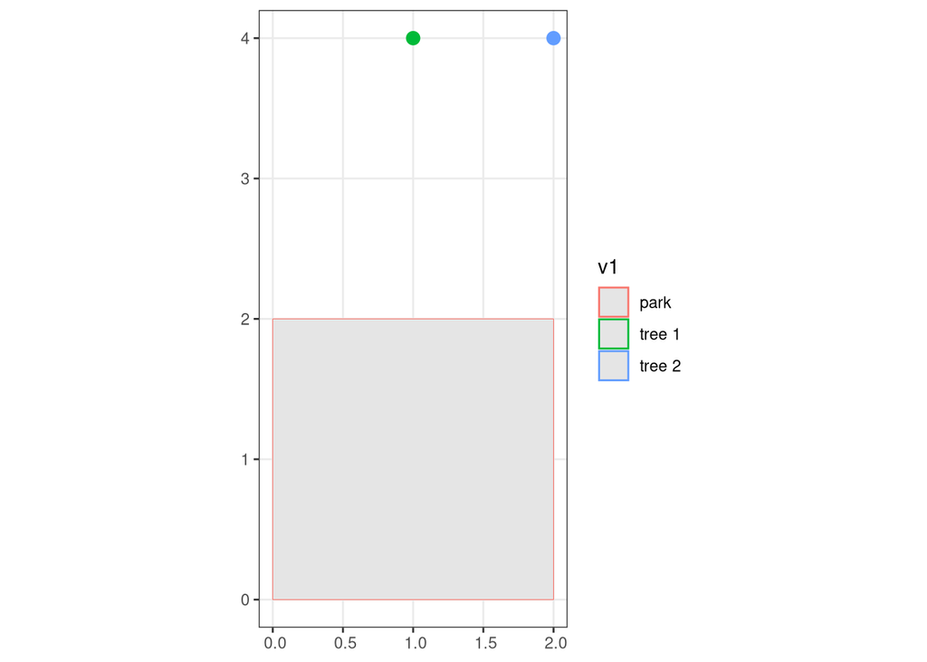

```r
rm( list = ls() )
#
library(sf)
#
# Single point (point as a vector)
p1_sfg <- st_point(c(1,4))     # a point
p2_sfg <- st_point(c(2,4))   # a point
#
# Polygon. ,
#
p1 <- rbind(c(0, 0), c(0, 2), c(2, 2), c(2,0), c(0,0) )
pol_sfg <- st_polygon(list(p1))
#
# Create sf object
p_sfc <- st_sfc(p1_sfg,
                p2_sfg,
                pol_sfg
                )
#
# STEP 3
#
df <- data.frame( v1 = c("tree 1", "tree 2", "park") ) # the attributes
p_sf <- st_sf(df,
              geometry = p_sfc)
#
# Plot them (to be introduced later in the computer practical)
#
library(ggplot2)
ggplot(p_sf) +
  geom_sf(aes( col = v1 ), size = 3) +
  theme_bw()
```

## Question

The following script creates

- gk.map which is an object containing a map with 4 divisions (sf object) labeled as A, B, C, D,
- gk.points which is an object containing the sampled POINT geometries

```r
rm( list = ls() )
library(spData)
library(sf)
gk.map <- st_read(
  system.file("shapes/columbus.shp", package="spData"),
  quiet=TRUE
  )
gk.map <- gk.map[1:4,]
gk.map$Division <- c("A","B","C","D")
gk.map <- gk.map[,c("Division")]
set.seed(2024)
gk.points <- st_sample(gk.map,
                    size = 30)
```

Calculate the number of points (provided in gk.points) inside each division/unit in the map (provided in gk.map) and insert the values below.

Match the labels of the divisions with the number of points they have

```r
# Intersection (first argument map, then points)
gk.inter <- st_intersects(gk.map, gk.points )
# Add point count to each polygon
gk.map$count <- lengths(gk.inter)
print(gk.map$count)
```

```
## [1] 12  7  9  2
```

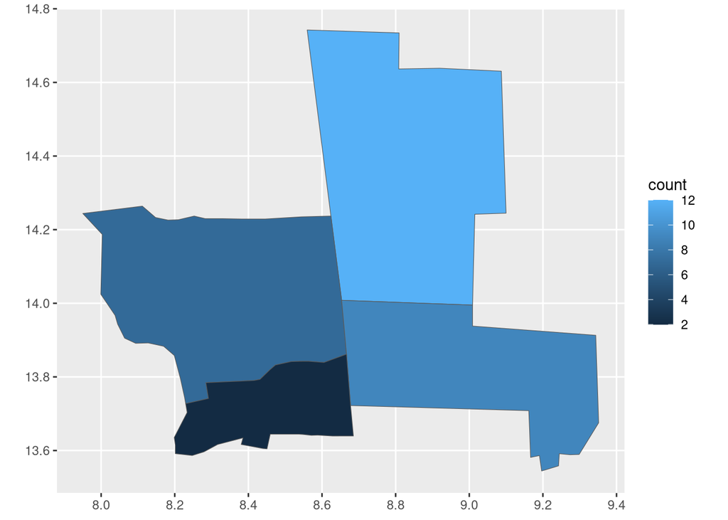

```r
# Map of number of points within polygons
library(ggplot2)
ggplot(gk.map) +
  geom_sf(aes(fill = count))
```

- A and 12
- B and 7
- C and 9
- D and 2